# 11. 최소제곱법 응용

```python
import numpy as np
import matplotlib.pyplot as plt

import pandas as pd

import matplotlib_inline.backend_inline
plt.rcParams.update({'font.size':14})
```

## 11.01. 날씨에 따른 자전거 대여량 예측

```python
url = "https://archive.ics.uci.edu/ml/machine-learning-databases/00560/SeoulBikeData.csv"
data = pd.read_csv(url,sep=',',encoding='unicode_escape')
```

```python
data.head()
```

|  | Date | Rented Bike Count | Hour | Temperature(°C) | Humidity(%) | Wind speed (m/s) | Visibility (10m) | Dew point temperature(°C) | Solar Radiation (MJ/m2) | Rainfall(mm) | Snowfall (cm) | Seasons | Holiday | Functioning Day |
| --- | --- | --- | --- | --- | --- | --- | --- | --- | --- | --- | --- | --- | --- | --- |
| 0 | 01/12/2017 | 254 | 0 | -5.2 | 37 | 2.2 | 2000 | -17.6 | 0.0 | 0.0 | 0.0 | Winter | No Holiday | Yes |
| 1 | 01/12/2017 | 204 | 1 | -5.5 | 38 | 0.8 | 2000 | -17.6 | 0.0 | 0.0 | 0.0 | Winter | No Holiday | Yes |
| 2 | 01/12/2017 | 173 | 2 | -6.0 | 39 | 1.0 | 2000 | -17.7 | 0.0 | 0.0 | 0.0 | Winter | No Holiday | Yes |
| 3 | 01/12/2017 | 107 | 3 | -6.2 | 40 | 0.9 | 2000 | -17.6 | 0.0 | 0.0 | 0.0 | Winter | No Holiday | Yes |
| 4 | 01/12/2017 | 78 | 4 | -6.0 | 36 | 2.3 | 2000 | -18.6 | 0.0 | 0.0 | 0.0 | Winter | No Holiday | Yes |

- 일자 vs 대여량 산점도

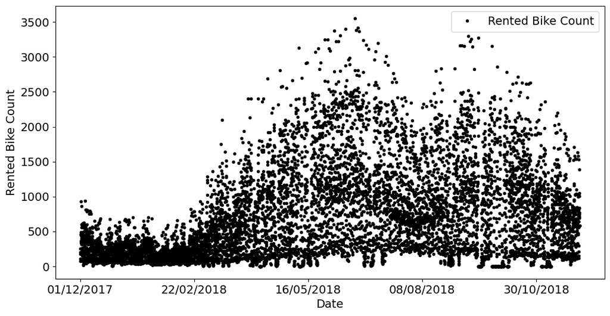

```python
data.plot(x='Date',y='Rented Bike Count',color='k',marker='.',linestyle='none', figsize=(12,6),ylabel='Rented Bike Count')
plt.show()
```

- 일자 vs 강우량 산점도
  - **강우량은 대부분 0으로 구성되어 있는 희소변수**

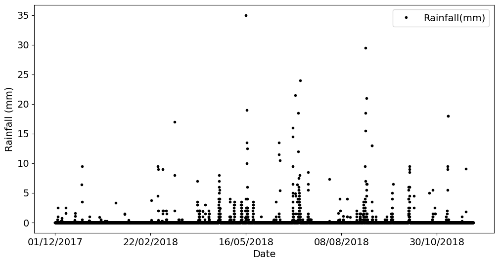

```python
data.plot(x='Date',y='Rainfall(mm)',color='k',marker='.',linestyle='none', figsize=(12,6),ylabel='Rainfall (mm)');
plt.show()
```

- 설명변수별 상관관계

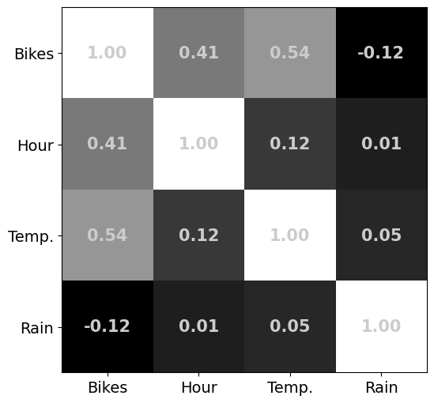

```python
columns2use = ['Rented Bike Count','Hour','Temperature(°C)','Rainfall(mm)']
colsshort = ['Bikes','Hour','Temp.','Rain'] # for axis labeleing

R = data[columns2use].corr()

plt.figure(figsize=(6,6))
plt.imshow(R.values,cmap='gray')
plt.xticks(range(4),labels=colsshort)
plt.yticks(range(4),labels=colsshort)

for (j,i),num in np.ndenumerate(R.values):
  plt.text(i,j,f'{num:.2f}',color=[.8,.8,.8],ha='center',va='center',fontweight='bold',fontsize=15)

plt.show()
```

- 가을과 겨울을 0, 봄과 여름을 1로 이진변수화

```python
data.replace(['Spring','Summer', 'Autumn','Winter'],[1,1,0,0], inplace=True)
```

- 설계행렬 시각화
  - 열은 회귀변수, 행은 관측치

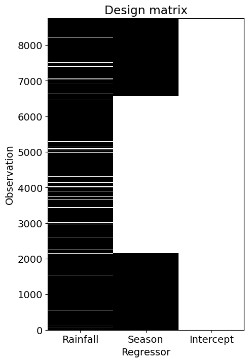

```python
desmat = data[['Rainfall(mm)','Seasons']].to_numpy()

# 절편 추가
desmat = np.append(desmat,np.ones((desmat.shape[0],1)),axis=1)

y = data[['Rented Bike Count']].to_numpy()

plt.figure(figsize=(5,8))
plt.imshow(desmat,aspect='auto',vmin=0,vmax=1,origin='lower',interpolation='nearest',cmap='gray')
plt.ylabel('Observation')
plt.xlabel('Regressor')
plt.title('Design matrix')
plt.xticks(range(3),labels=['Rainfall','Season','Intercept'])
plt.show()
```

- 강우량 vs 자전거 대여량 시각화

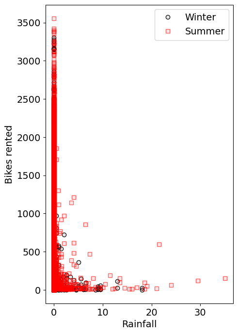

```python
plt.figure(figsize=(5,8))

plt.plot(desmat[desmat[:,1]==0,0],y[desmat[:,1]==0],'o',markerfacecolor=(0,0,0,.1),markeredgecolor=(0,0,0,.9),label='Winter')
plt.plot(desmat[desmat[:,1]==1,0],y[desmat[:,1]==1],'s',markerfacecolor=(1,0,0,.1),markeredgecolor=(1,0,0,.6),label='Summer')

plt.xlabel('Rainfall')
plt.ylabel('Bikes rented')
plt.legend()
plt.show()
```

#### 최소제곱법을 사용하여 모델을 데이터에 적합

#### `np.linalg.lstsq()`

```python
beta = np.linalg.lstsq(desmat,y,rcond=None)
beta[0]
```

```
array([[-80.52367456],
       [369.12668112],
       [530.49459615]])
```

- $R^2 = 0.097$

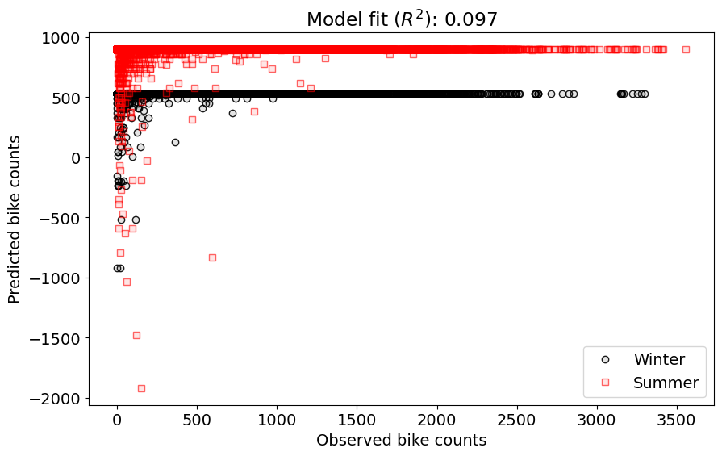

```python
yHat = desmat@beta[0]

modelfit = np.corrcoef(y.T,yHat.T)[0,1]**2

plt.figure(figsize=(10,6))
plt.plot(y[desmat[:,1]==0],yHat[desmat[:,1]==0],'o',markerfacecolor=(0,0,0,.1),markeredgecolor=(0,0,0,.9),label='Winter')
plt.plot(y[desmat[:,1]==1],yHat[desmat[:,1]==1],'s',markerfacecolor=(1,0,0,.1),markeredgecolor=(1,0,0,.6),label='Summer')
plt.legend()
plt.xlabel('Observed bike counts')
plt.ylabel('Predicted bike counts')
plt.title(f'Model fit ($R^2$): {modelfit:.3f}')
plt.show()
```

#### 강우량이 없는 날을 제거하여 모델 적합

```python
desmat = data[['Rainfall(mm)','Seasons']].to_numpy()
desmat = np.append(desmat, np.ones((desmat.shape[0],1)),axis=1)
y = data[['Rented Bike Count']].to_numpy()
```

```python
desmat_norain = desmat[desmat[:,0]>0,:]
y_norain = y[desmat[:,0]>0,:]
```

```python
beta_norain = np.linalg.lstsq(desmat_norain, y_norain, rcond=None)
yHat_norain = desmat_norain @ beta_norain[0]

modelfit = np.corrcoef(y_norain.T,yHat_norain.T)[0,1]**2
```

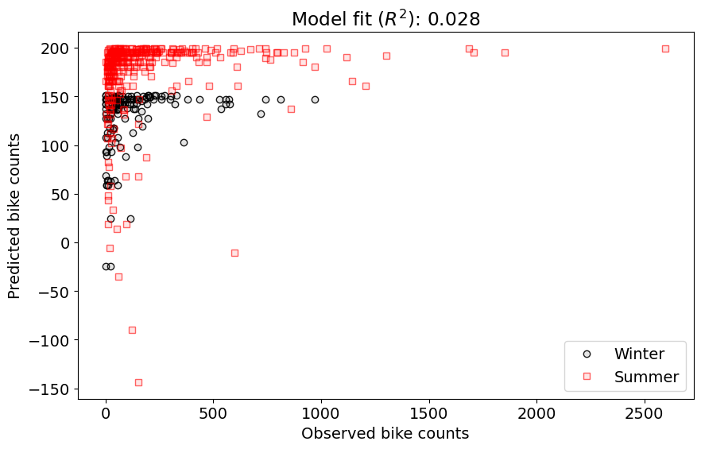

```python
plt.figure(figsize=(10,6))
plt.plot(y_norain[desmat_norain[:,1]==0],yHat_norain[desmat_norain[:,1]==0],'o',
         markerfacecolor=(0,0,0,.1),markeredgecolor=(0,0,0,.9),label='Winter')
plt.plot(y_norain[desmat_norain[:,1]==1],yHat_norain[desmat_norain[:,1]==1],'s',
         markerfacecolor=(1,0,0,.1),markeredgecolor=(1,0,0,.6),label='Summer')

plt.legend()
plt.xlabel('Observed bike counts')
plt.ylabel('Predicted bike counts')
plt.title(f'Model fit ($R^2$): {modelfit:.3f}')
plt.show()
```

#### '계절' 변수 대신 '기온'변수를 선택하여 다시 적합

- $R^2$가 크게 증가

```python
desmat = data[['Rainfall(mm)','Temperature(°C)']].to_numpy()
desmat = np.append(desmat,np.ones((desmat.shape[0],1)),axis=1)
```

```python
beta = np.linalg.lstsq(desmat,y,rcond=None)
yHat = desmat@beta[0]
```

```python
modelfit = np.corrcoef(y.T,yHat.T)[0,1]**2
```

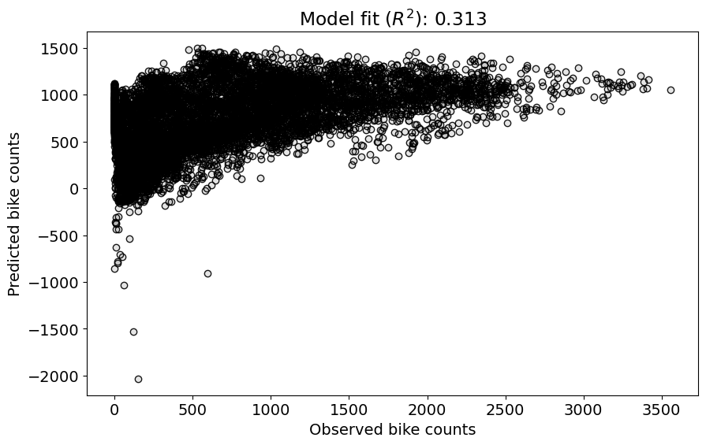

```python
plt.figure(figsize=(10,6))
plt.plot(y,yHat,'o',markerfacecolor=(0,0,0,.1),markeredgecolor=(0,0,0,.9))
plt.xlabel('Observed bike counts')
plt.ylabel('Predicted bike counts')
plt.title(f'Model fit ($R^2$): {modelfit:.3f}')
plt.show()
```

### `statsmodels` 사용

```python
import statsmodels.api as sm
```

```python
desmat_df  = data[['Rainfall(mm)','Seasons']]
obsdata_df = data['Rented Bike Count']
```

- 절편 추가

#### `sm.add_constant()`

```python
desmat_df = sm.add_constant(desmat_df)
```

- 모델 적합

#### `sm.OLS(Y, X).fit()`

```python
model = sm.OLS(obsdata_df, desmat_df).fit()
print( model.summary() )
```

```
                            OLS Regression Results
==============================================================================
Dep. Variable:      Rented Bike Count   R-squared:                       0.097
Model:                            OLS   Adj. R-squared:                  0.097
Method:                 Least Squares   F-statistic:                     468.8
Date:                Sun, 03 Dec 2023   Prob (F-statistic):          3.80e-194
Time:                        23:06:05   Log-Likelihood:                -68654.
No. Observations:                8760   AIC:                         1.373e+05
Df Residuals:                    8757   BIC:                         1.373e+05
Df Model:                           2
Covariance Type:            nonrobust
================================================================================
                   coef    std err          t      P>|t|      [0.025      0.975]
--------------------------------------------------------------------------------
const          530.4946      9.313     56.963      0.000     512.239     548.750
Rainfall(mm)   -80.5237      5.818    -13.841      0.000     -91.928     -69.120
Seasons        369.1267     13.127     28.121      0.000     343.395     394.858
==============================================================================
Omnibus:                     1497.901   Durbin-Watson:                   0.240
Prob(Omnibus):                  0.000   Jarque-Bera (JB):             2435.082
Skew:                           1.168   Prob(JB):                         0.00
Kurtosis:                       4.104   Cond. No.                         2.80
==============================================================================

Notes:
[1] Standard Errors assume that the covariance matrix of the errors is correctly specified.
```

### 다중공선성 (multicollinearity)

- **설계 행렬 내부에 선형 종속성이 있다는 것을 의미**

  $\rightarrow$ **설계 행렬이 축소계수 또는 특이 행렬**
- 축소계수 설계 행렬은 왼쪽 역행렬이 존재하지 않으므로, 최소제곱 문제를 분석적으로 해결할 수 없음

### 정규화 (regularization)

- **통계 모델의 수치 안정성을 개선하거나, 특이 행렬 또는 나쁜 상태의 행렬을 최대계수로 변환 하거나, 과적합을 줄여 일반화 가능성을 개선하는 것을 목표**

  릿지 (Ridge, L2), 라쏘 (Lasso, L1), 티흐노프(Tikhonov), 수축(Shrinkage) 등 존재
- **정규화 기법은 설계 행렬을 일정량 이동**

  **(행렬을 이동 ($A+\lambda I$)하면 축소계수 행렬을 최대계수 행렬로 변환할 수 있음)**
- 설계 행렬이 축소계수 행렬일 때, 정규화된 정방 설계 행렬이 최대계수 행렬이 됨
- 정규화는 또한 행렬에서 정보의 '퍼짐'을 측정하는 조건수(가장 큰 특잇값과 가장 작은 특잇값의 비율)를 감소

  $\rightarrow$ 행렬의 수치 안정성이 증가
- **정규화의 통계적 의미는 이상치이거나 대표성이 없는, 혹은 새로운 데이터 집합에서 관찰될 가능성이 낮은 개별 데이터 점에 대한 모델의 민감도를 낮추어 '평활화' 하는 것**

#### **설계 행렬을 프로베니우스 노름의 일부 크기만큼 이동하여 정규화하는 방법**

- $\gamma$는 정규화의 양을 결정하는 초매개변수

$$\beta = (X^T X + \gamma ||X||^2_F I)^{-1} X^T y$$

- $\gamma=0.1$과 같이 정해진 $\gamma$는 행렬의 수치 범위에 따라 설계 행렬에 큰 영향을 미칠 수도 있고 무시될 수도 있음

  $\rightarrow$ $\gamma$를 정규화의 비율로 해석하여 행렬의 수치 범위에 따라 크기를 조정

#### 실제로는 프로베니우스 노름 대신 설계 행렬의 고윳값의 평균을 사용하는 것이 더 일반적

## 11.02. 다항식 회귀

### 다항식 회귀 (polynomial regression)

- 독립변수 $x$축의 값을 더 높은 차수로 올림
- 다항식의 차수는 가장 큰 $i$차수

$$y = \beta_0 x^0 + \beta_1 x^1 + \dots + \beta_n x^n$$

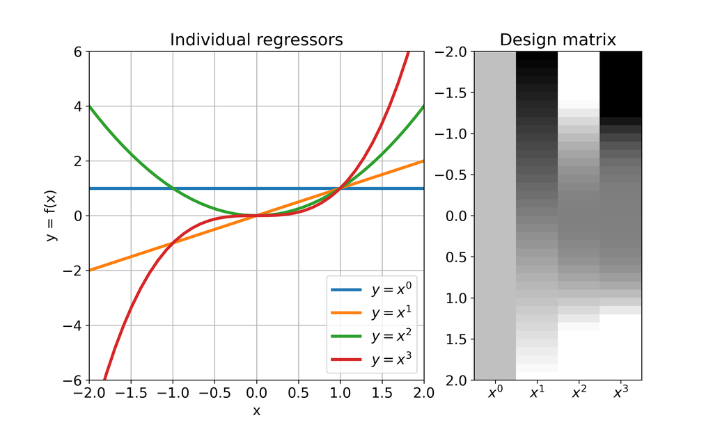

- **다항식의 차수가 너무 낮은 모델은 데이터를 제대로 이해하지 못함 (과소 예측)**
- **다항식의 차수가 너무 높은 모델은 데이터에 과적합되어, 이상치에 민감한 형태 $\rightarrow$ 새로운 데이터로 일반화 하지 못함**

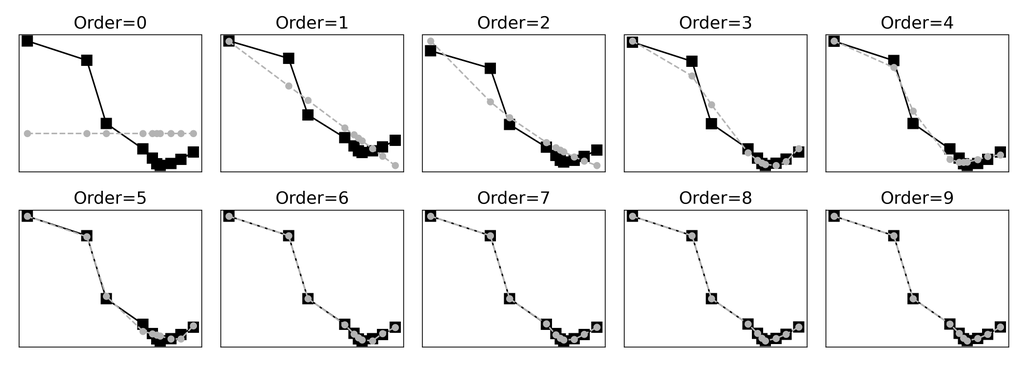

#### 다항식 회귀 예시

- 데이터

```python
year       = [1534, 1737, 1803, 1928, 1960, 1975, 1987, 2023, 2057, 2100 ]
doubleTime = [ 697,  594,  260,  125,   76,   47,   37,   48,   70,  109 ]

N = len(year)
```

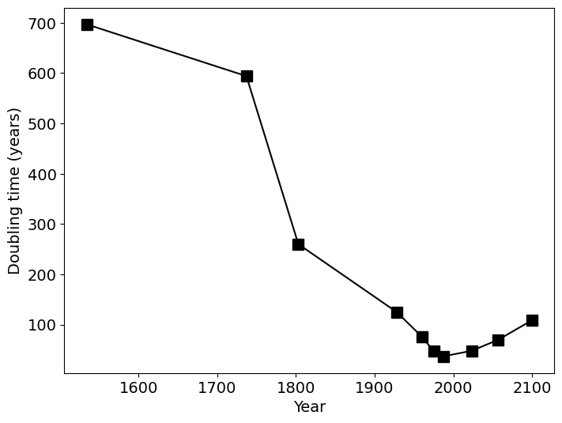

```python
plt.figure(figsize=(8,6))
plt.plot(year,doubleTime,'ks-',markersize=10)

plt.xlabel('Year')
plt.ylabel('Doubling time (years)')
plt.show()
```

- 3차 다항식 설계 행렬 생성

```python
X = np.zeros((N,4))

for i in range(4):
  X[:,i] = np.array(year)**i

print(X.astype(int))
```

```
[[          1        1534     2353156  -685225992]
 [          1        1737     3017169   945855257]
 [          1        1803     3250809  1566241331]
 [          1        1928     3717184 -1423203840]
 [          1        1960     3841600 -1060398592]
 [          1        1975     3900625  -886200217]
 [          1        1987     3948169  -744922789]
 [          1        2023     4092529  -310748425]
 [          1        2057     4231249   113744601]
 [          1        2100     4410000   671065408]]
```

- 3차 다항식 모형 적합

```python
beta = np.linalg.lstsq(X,doubleTime, rcond=None)
```

- 예측값 생성

```python
yHat = X@beta[0]
```

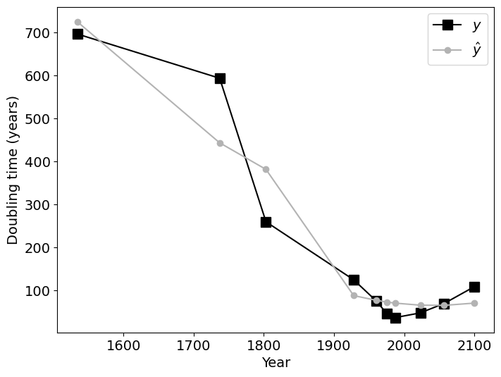

```python
plt.figure(figsize=(8,6))
plt.plot(year,doubleTime,'ks-',markersize=10,label=r'$y$')
plt.plot(year,yHat,'o-',color=[.7,.7,.7],label=r'$\hat{y}$')

plt.legend()
plt.xlabel('Year')
plt.ylabel('Doubling time (years)')
plt.show()
```

#### `np.polyfit()`

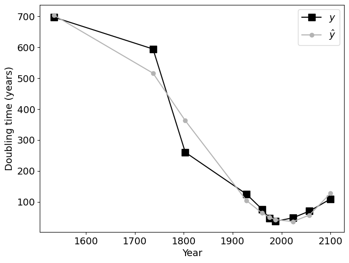

```python
beta = np.polyfit(year,doubleTime, 3)
yHat = np.polyval(beta,year)

plt.figure(figsize=(8,6))
plt.plot(year,doubleTime,'ks-',markersize=10,label=r'$y$')
plt.plot(year,yHat,'o-',color=[.7,.7,.7],label=r'$\hat{y}$')

plt.legend()
plt.xlabel('Year')
plt.ylabel('Doubling time (years)')
plt.show()
```

## 11.03. 그리드 서치

- 매개변수 공간을 샘플링하고, 각 매개변수값으로 데이터에 대한 모델 적합도를 계산한 다음

  최고의 모델 적합도를 가지는 매개변수 값을 선택
- 그리드 서치는 비선형 모델에서 매개변수를 찾는 데 유용
- 데이터

```python
numcourses = [13,4,12,3,14,13,12,9,11,7,13,11,9,2,5,7,10,0,9,7]
happiness  = [70,25,54,21,80,68,84,62,57,40,60,64,45,38,51,52,58,21,75,70]
```

- 절편 추가 이후 최소제곱법 적용

```python
X = np.hstack((np.ones((20,1)),np.array(numcourses,ndmin=2).T))
beta = np.linalg.lstsq(X,happiness,rcond=None)[0]
```

- 100회의 그리드 서치

```python
gridResolution = 100

intercepts = np.linspace(0, 80, gridResolution)
slopes = np.linspace(0, 6, gridResolution)

SSEs = np.zeros((len(intercepts), len(slopes)))

for inti in range(len(intercepts)):
  for slopei in range(len(slopes)):

    yHat = X @ np.array([intercepts[inti],slopes[slopei]]).T

    SSEs[inti,slopei] = np.sum((yHat-happiness)**2)
```

```python
i,j = np.unravel_index( np.argmin(SSEs),SSEs.shape )
empIntercept,empSlope = intercepts[i], slopes[j]
```

```python
print('최소제곱법: ')
print(f'   절편: {beta[0]:.2f}, 계수: {beta[1]:.2f}')
print(' ')
print('그리드 서치: ')
print(f'   절편: {empIntercept:.2f}, 계수: {empSlope:.2f}')
```

```
최소제곱법:
   절편: 23.13, 계수: 3.70

그리드 서치:
   절편: 22.63, 계수: 3.76
```

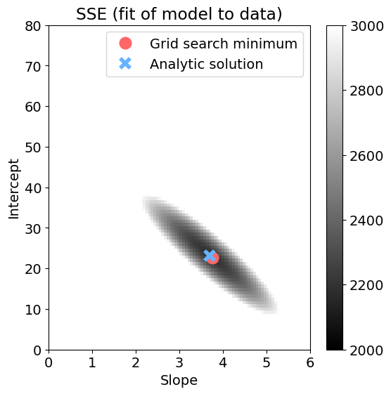

```python
plt.figure(figsize=(6,6))
plt.imshow(SSEs,vmin=2000,vmax=3000,
           extent=[slopes[0],slopes[-1],intercepts[0],intercepts[-1]],
           origin='lower',aspect='auto',cmap='gray')
plt.plot(empSlope,empIntercept,'o',color=[1,.4,.4],markersize=12,label='Grid search minimum')
plt.plot(beta[1],beta[0],'x',color=[.4,.7,1],markeredgewidth=4,markersize=10,label='Analytic solution')
plt.colorbar()
plt.xlabel('Slope')
plt.ylabel('Intercept')
plt.title('SSE (fit of model to data)')
plt.legend()
plt.show()
```